# CURSO R NIVEL BÁSICO

Mayo, 2015

## **Qué es R ?**

- **R es un dialecto de S**

## **Qué es S ?**

- S es un lenguaje de programación desarrollado por [Jhon Chambers](http://en.wikipedia.org/wiki/John_Chambers_%28statistician%29) en [Bell Labs](https://www.bell-labs.com/) en 1976.
- Inicialmente se generó como un entorno estadístico interno (implementado en Fortran).
- En **1988** es reescrito en lenguaje C (versión 3)
- En **1998** se lanza la versión 4, que actualmente se maneja.
- Bell Labs –> Insightful Corp (licencia, lenguaje, 2 M.)
- En **2004** Insightful añade GUIs y varías características, S-PLUS
- En **2008** Insightful Corp –> TIBCO (lenguaje, 25 M)

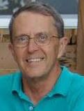

**=**

[figure not shown]

## **Historia de R**

- Fue desarrollado en **1991** por [Ross Ihaka](https://www.stat.auckland.ac.nz/~ihaka/) y [Robert Gentleman](http://en.wikipedia.org/wiki/Robert_Gentleman_%28statistician%29) en la [Universidad de Auckland](https://www.auckland.ac.nz/en.html).
- En **1993** se anuncia al público en general.
- En **1995**, [Martin Mächler](http://stat.ethz.ch/people/maechler) convence a Ross y Robert de distribuir a R mediante la licencia GNU (General Public License).
- EN **1996**, se crean las listas de correo públicas [R-help](https://stat.ethz.ch/mailman/listinfo/r-help) y [R-devel](https://stat.ethz.ch/mailman/listinfo/r-devel).
- En **1997** se forma el **R Core Group** o **R Core Team**, encargado de controlar el código fuente de R.
- En el **2000** se publica la primera versión de R 1.0.0.
- En **marzo 2015** se publica la versión 3.1.3.

**+** **+** **=**

[figure not shown]

## **Características de R**

**Ventajas**

- R es un software de distribución libre (GNU Licence)
  - Ejecutar el programa para cualquier propósito.
  - Visualizar el código fuente y modificarlo a conveniencia.
  - Redistribuir copias.
  - Proponer y compartir mejoras al público.
- Lenguaje intuitivo.
- Gráficos estadísticos de excelente calidad.

**Desventajas**

- Almacenamiento en memoria física de objetos (nuevas mejoras)
- Su funcionalidad se basa en contribuciones de usuarios (implementar métodos a la medida).
- Moderada calidad de gráficos 3D dinámincos (nuevas mejoras)

## **Diseño del sistema R**

El sistema de **R** puede considerarse como la interacción de dos componentes principales:

**1. Sistema Base de R.**

- El paquete base de R contiene las funciones fundamentales que permiten correr el programa en sí.

Adicionalmente, al momento de instalar el programa se cargan por default paquetes estándar que permiten ampliar la capacidad de los gráficos, funciones estadísticas clásicas entre otros.

Los paquetes estándar pueden ser visualizados a través del siguiente comando:

```r
# no se muestran advertencias
options(warn=-1)
search()
```

```
## [1] ".GlobalEnv"        "package:stats"     "package:graphics"
## [4] "package:grDevices" "package:utils"     "package:datasets"
## [7] "package:methods"   "Autoloads"         "package:base"
```

- Las funciones internas de estos paquetes pueden ser modificadas únicamente por el R Core Team.

## **Diseño del sistema R**

**2. El resto.**

- Paquetes específicos para analizar un determinado tipo de fenómeno o implementaciones de nuevos algoritmos, por ejemplo:

**tseries, ggplot2, knitr, shiny, etc.**

- En la actualidad existen alrededor de **6.200** paquetes válidos en el repositorio [CRAN](http://cran.r-project.org), adicionalmente, existen otros paquetes almacenados en los repositorios:
  - [Omegahat](http://www.omegahat.org/R)
  - [Bioconductor Project](http://bioconductor.org)
  - [R Forge](https://r-forge.r-project.org/), entre otros.

## **Instalando paquetes**

Una de las principales ventajas de R es su capacidad para incrementar su funcionalidad mediante la incorporación de nuevos paquetes o librerías.

- Para instalar un paquete se utiliza la linea de código:

```r
install.packages("pckgname")
```

Ciertos paquetes de R requieren la instalación de otros paquetes adicionales debido que entre estos comparten algunas funciones, por lo cual es necesario adicionar el siguiente parámetro:

```r
install.packages("pckgname", dependencies=TRUE)
```

En el caso que se desee instalar un lista de \(n\) paquetes planteamos la siguiente solución:

```r
paquetes <- c("pckg_1","pckg_2", ... , "pckg_n")
install.packages(paquetes, dependencies=TRUE)
# funciones apply
# sapply(X=paquetes, FUN=install.packages, dependencies=TRUE)
```

## **Ejemplos**

- Para instalar el paquete de nombre "devtools", utilizamos la línea de código:

```r
install.packages("devtools", dependencies = TRUE)
```

```r
paquetes <- c("foreign", "forecast", "gWidgets")
install.packages(paquetes, dependencies=TRUE)
# funciones apply
# sapply(X=paquetes, FUN=install.packages, dependencies=TRUE)
```

## **Instalando paquetes**

- Algunos de los paquetes se encuentran en **formato binario**, para su instalación basta adicionar el parámetro *type="source"*.

```r
install.packages("pckgname", repos="http://www.omegahat.org/R", type="source")
install.packages("pckgname", repos="http://r-forge.r-project.org", type="source")
install.packages("pckgname", repos="http://www.bioconductor.org/packages/2.10/bioc", type="source")
```

- Para visualizar el **listado completo de los paquetes instalados** podemos recurrir al comando:

```r
library()
```

- Para conocer la totalidad de paquetes que se encuentran albergados en la CRAN, y a su vez verificar cuales de ellos se encuentran **instalados y disponibles** para su uso, empleamos los comandos:

```r
# paquetes instalados
installed.packages()
.packages(all.available = TRUE)  # forma mas compacta
# paquetes disponibles
available.packages()
```

## **Cargando paquetes**

```r
# paquetes cargados
(.packages())
```

```
## [1] "stats"     "graphics"  "grDevices" "utils"     "datasets"  "methods"
## [7] "base"
```

- Para cargar un paquete nuevo al área de trabajo utilizamos la función `library()`:

```r
library("devtools")
```

```r
paquetes <- c("foreign", "forecast", "gWidgets")
sapply(X=paquetes, FUN=library,character.only=TRUE)
```

```r
# paquetes cargados
(.packages())
```

```
## [1] "devtools"  "stats"     "graphics"  "grDevices" "utils"     "datasets"
## [7] "methods"   "base"
```

## **Git & Github**

- GitHub es un repositorio de archivos y proyectos que emplea un sistema de control de versiones conocido como Git y permite almacenar el código en repositorios de forma pública.

[figure not shown]

- La instalación y sincronización de Git & Github con RStudio se realiza mediante:
  - Descargar e instalar la plataforma específica de [Git](http://www.git-scm.com/) con las opciones por default.
  - Configurar Git con los comandos globales a través de la versión bash, esto permitirá que Git tenga conexión con los repositorios de Github para el envió/recepción de archivos, teclear lo siguiente:

```r
  git config --global user.name "Usuario de Github"

  git config --global user.email "Github-email@something.com"
```

- Por último, abrir RStudio y configurar la ruta del ejecutable de Git: Ir a Tools > Options > Git/SVN.

## **Estructuras de Datos**

- Las estructuras de datos en R se organizan por su **dimensionalidad y tipo de elementos** (Homogeneos y heterogeneos):

| Dimensión | Homogeneos | Heterogeneos |
| --- | --- | --- |
| 1d | Atomic vector | List |
| 2d | Matrix | Data Frame |
| nd | Array |  |

- **Observación.** R no tiene estructuras 0d (magnitudes escalares), los números y strings se consideran como vectores de longitud 1

## **Vectores**

- La estructura de datos básica de R son los vectores, estos se dividen en:
  - **Vectores atómicos y Listas**
- Presentan tres propiedades comunes:
  - Tipo (Qué es?). `typeof()`
  - Longitud (Número de elementos) `length()`
  - Atributos (Metadata). `attributes()`
- Para probar que una estructura de datos es un vector (atómico o lista) se utiliza la función:

```r
is.vector(x)
```

- `is.vector(x)` retorna `TRUE` si `x` es un vector atómico o una lista.

## **Vectores atómicos**

- Los elementos de un vector atómico son del **mismo tipo** (tipos comunes):
  - logical
  - integer
  - double (comunmente llamados numeric)
  - character
- Un vector es creado mediante la función `c()`, e ingresamos a la *i-ésima* componente con `x[i]`

```r
dbl_var <- c(1, 2, -1)
int_var <- c(3L, 7L, 1L) # con el sufijo L se declaran números enteros
log_var <- c(FALSE, TRUE, F, T) # TRUE y FALSE (T, F) se usan para crear vectores lógicos
chr_var <- c("Source", "Stat", "Lab")
```

```r
# tercera componente de dbl_var
dbl_var[3]
```

[output not shown]

```r
c(1, c(2, c(3,4))) ; c(1, 2, 3, 4) # los vectores pueden ser anidados
```

```
## [1] 1 2 3 4
```

```
## [1] 1 2 3 4
```

## **Tipos y Tests**

- Dado un vector se puede determinar su tipo con `typeof()` o verificar un tipo específico con una "is" función:
  - `is.character()`
  - `is.double()`
  - `is.integer()`
  - `is.logical()`

```r
dbl_var <- c(1, 2, -1)
typeof(dbl_var)
```

```
## [1] "double"
```

```r
is.double(dbl_var)
```

```
## [1] TRUE
```

## **Tipos y Tests**

```r
dbl_var <- c(1, 2, -1)
is.atomic(dbl_var)
```

```
## [1] TRUE
```

```r
int_var <- c(3L, 7L, 1L)
typeof(int_var)
```

```
## [1] "integer"
```

```r
is.integer(int_var)
```

```
## [1] TRUE
```

```r
is.atomic(int_var)
```

```
## [1] TRUE
```

## **Tipos y Tests**

- **`is.numeric()` retorna `TRUE` para vectores double e integer**

```r
dbl_var <- c(1, 2, -1)
is.numeric(dbl_var)
```

```
## [1] TRUE
```

```r
int_var <- c(3L, 7L, 1L)
is.numeric(int_var)
```

```
## [1] TRUE
```

## **Coerción**

- Los elementos de un vector son del mismo tipo, es por eso que si combinamos tipos diferentes, serán coercionados al tipo más flexible dado por la jerarquía:
  - **character <= double <= integer <= logical**

```r
x <- c("ssl", 1, TRUE)
str(x)
```

```
##  chr [1:3] "ssl" "1" "TRUE"
```

- Se usa las funciones "as" para coercionar un vector a un determinado tipo: `as.character(), as.double(), as.integer(), as.logical()`
- Las funciones `+, abs, log, etc` coercionan a `double o integer`
- Las funciones `&, |, any, all, etc` coercionan a `logical`

```r
x <- c(1L, 3L) ; y <- c(2L, 5L) ; str(x + y)
```

```
##  int [1:2] 3 8
```

## **Coerción**

```r
x <- c(FALSE, TRUE, FALSE, TRUE)
as.numeric(x) # TRUE coerciona a 1 y FALSE a 0
```

```
## [1] 0 1 0 1
```

```r
sum(x) # número total de TRUEs
```

```
## [1] 2
```

```r
mean(x) # proporción de TRUEs
```

```
## [1] 0.5
```

## **Listas**

- Una lista puede contener elementos de cualquier tipo.
- Para construir una lista se utiliza la función `list()` en lugar de `c()`.

```r
x <- list(1:3, c("Source", "Stat", "Lab"), c(TRUE, FALSE), c(1.3, 4.5))
str(x)
```

```
## List of 4
##  $ : int [1:3] 1 2 3
##  $ : chr [1:3] "Source" "Stat" "Lab"
##  $ : logi [1:2] TRUE FALSE
##  $ : num [1:2] 1.3 4.5
```

```r
is.atomic(x)
```

```
## [1] FALSE
```

```r
# coercionamos un objeto a una lista
as.list(c("ssl", 4, 0.5))
```

[output not shown]

## **Listas**

```r
x <- list(1:3, c("Source", "Stat", "Lab"), c(TRUE, FALSE), c(1.3, 4.5))
typeof(x)
```

```
## [1] "list"
```

```r
# probamos si x es una lista
is.list(x)
```

```
## [1] TRUE
```

```r
# pasamos a vector considerando las reglas de coerción
unlist(x)
```

```
##  [1] "1"      "2"      "3"      "Source" "Stat"   "Lab"    "TRUE"
##  [8] "FALSE"  "1.3"    "4.5"
```

## **Listas**

- Una lista es un **vector recursivo**, es decir una lista puede contener otra lista (diferencia principal con los **vectores atómicos**)

```r
x <- list(list(list("Source", "Stat")))
str(x)
```

```
## List of 1
##  $ :List of 1
##   ..$ :List of 2
##   .. ..$ : chr "Source"
##   .. ..$ : chr "Stat"
```

```r
# son equivalentes. un vector no puede contener otro vector
c(1, c(2, c(3,4)))  ;  c(1, 2, 3, 4)
```

```
## [1] 1 2 3 4
```

```
## [1] 1 2 3 4
```

## **Elementos de una lista**

- Para acceder al elemento `i` de la lista se utiliza `x[i]`, en cambio para acceder al objeto que contiene el elemento `i` se utiliza `x[[i]]` o `x$nomb_obj`.

```r
x <- list(1:3, c("Source", "Stat", "Lab"), nomb_obj=c(TRUE, FALSE), c(1.3, 4.5))
x[4]
```

```
## [[1]]
## [1] 1.3 4.5
```

```r
x[[4]]
```

```
## [1] 1.3 4.5
```

```r
x$nomb_obj
```

```
## [1]  TRUE FALSE
```

## **Quiz**

1. Enumere los tipos de datos que R puede almacenar en un vector.
2. Cuál es la diferencia entre un vector y una lista ?. Entre una matriz y un data frame ?.
3. Cuál es la jerarquía de coerción para los vectores ?.

## **Función structure**

La función `str()` (structure) presenta una descripción compacta de la estructura de datos.

```r
str(cars)
```

```
## 'data.frame':    50 obs. of  2 variables:
##  $ speed: num  4 4 7 7 8 9 10 10 10 11 ...
##  $ dist : num  2 10 4 22 16 10 18 26 34 17 ...
```